# IODS Final Assignment

Gintare Baublyte (gintare.baublyte@helsinki.fi)

07 March 2017

# Abstract

The purpose of this research is to analyse what variables affect job satisfaction. Number of variables were analysed in relation to high or low job satisfaction. In addition to that logistic regression was used to fit a model with a number of variables. The results show that last performance evaluation and average monthly hours at work seem to have the highest effect on job satisfaction. However, the model is not very good at explaining the dependant variable. The topic needs further exploration with a different set of data.

# Research question

The research will try to answer what variables affect job satisfaction.

# Data

The dataset is related to human resources and it is great for analysing why some of the employees leave their positions pre-maturely. It is **simulated** data. However, I will be using this data to analyse how emplyees’ work satisfaction depends on their workload, and other factors. The dataset can be downloaded from here: https://www.kaggle.com/ludobenistant/hr-analytics.

The data represents different variables that could affect work satisfation level.

The original data was wrangled prior to this analysis. The data wrangling file can be accessed here: https://github.com/GintareBaublyte/IODS-final/blob/master/create_hr.R

In the wrangled dataset, there are 4140 observations and 10 variables. In the original data there was a number of people that worked in different departments. Since majority of them was from the sales department and since the general environment and work practices can be highly different between departments, I have decided to focus only on the sales department. Thus the department variable from the origical dataset was removed after filtering out only that data that was related to the sales department.

Additionally, I have created a new logical variable “*satisfied*” that is **true** if the work satisfaction level is higher than the average (0.6144) and **false** otherwise.

```r
str(hr_sales)
```

```
## 'data.frame':    4140 obs. of  10 variables:
##  $ satisfaction_level   : num  0.38 0.8 0.11 0.72 0.37 0.41 0.1 0.92 0.89 0.42 ...
##  $ last_evaluation      : num  0.53 0.86 0.88 0.87 0.52 0.5 0.77 0.85 1 0.53 ...
##  $ number_project       : int  2 5 7 5 2 2 6 5 5 2 ...
##  $ average_montly_hours : int  157 262 272 223 159 153 247 259 224 142 ...
##  $ time_spend_company   : int  3 6 4 5 3 3 4 5 5 3 ...
##  $ Work_accident        : int  0 0 0 0 0 0 0 0 0 0 ...
##  $ left                 : int  1 1 1 1 1 1 1 1 1 1 ...
##  $ promotion_last_5years: int  0 0 0 0 0 0 0 0 0 0 ...
##  $ salary               : Factor w/ 3 levels "high","low","medium": 2 3 3 2 2 2 2 2 2 2 ...
##  $ satisfied            : logi  FALSE TRUE FALSE TRUE FALSE FALSE ...
```

The variables in the dataset are:  
1. *satisfaction_level* - employee satisfaction level (0-1)  
2. *last_evaluation* - evaluation of employee performance (0-1)  
3. *number_project* - number of projects completed while at work  
4. *average_montly_hours* - average monthly hours at workplace  
5. *time_spend_company* - number of years spent in the company  
6. *Work_accident* - whether the employee had a workplace accident or not (1 or 0)  
7. *left* - whether the employee left the workplace or not (1 or 0)  
8. *promotion_last_5years* - whether the employee was promoted in the last five years or not (1 or 0)  
9. *salary* - relative level of salary (low med high)  
10. *satisfied* - satisfaction level, which is true if higher than average and false otherwise

## Variables

```r
summary(hr_sales)
```

```
##  satisfaction_level last_evaluation  number_project  average_montly_hours
##  Min.   :0.0900     Min.   :0.3600   Min.   :2.000   Min.   : 96.0
##  1st Qu.:0.4300     1st Qu.:0.5500   1st Qu.:3.000   1st Qu.:156.0
##  Median :0.6400     Median :0.7000   Median :4.000   Median :201.0
##  Mean   :0.6144     Mean   :0.7097   Mean   :3.776   Mean   :200.9
##  3rd Qu.:0.8200     3rd Qu.:0.8600   3rd Qu.:5.000   3rd Qu.:245.0
##  Max.   :1.0000     Max.   :1.0000   Max.   :7.000   Max.   :310.0
##  time_spend_company Work_accident         left
##  Min.   : 2.000     Min.   :0.0000   Min.   :0.0000
##  1st Qu.: 3.000     1st Qu.:0.0000   1st Qu.:0.0000
##  Median : 3.000     Median :0.0000   Median :0.0000
##  Mean   : 3.534     Mean   :0.1418   Mean   :0.2449
##  3rd Qu.: 4.000     3rd Qu.:0.0000   3rd Qu.:0.0000
##  Max.   :10.000     Max.   :1.0000   Max.   :1.0000
##  promotion_last_5years    salary     satisfied
##  Min.   :0.00000       high  : 269   Mode :logical
##  1st Qu.:0.00000       low   :2099   FALSE:1912
##  Median :0.00000       medium:1772   TRUE :2228
##  Mean   :0.02415                     NA's :0
##  3rd Qu.:0.00000
##  Max.   :1.00000
```

### Performance evaluation

The plot shows an interesting relationship between the last evaluation score and satisfaction with job. It seems that employees satisfied with their job received a higher score on their last performance evaluation. The middle 50% of employees that aren’t satisfied with their job received scores from around 0.5 to bit over 0.8 with a mean of 0.65. Those who are satisfied with their job (mid 50% of them) received scores from 0.6 to 0.9 with a mean of 0.75.

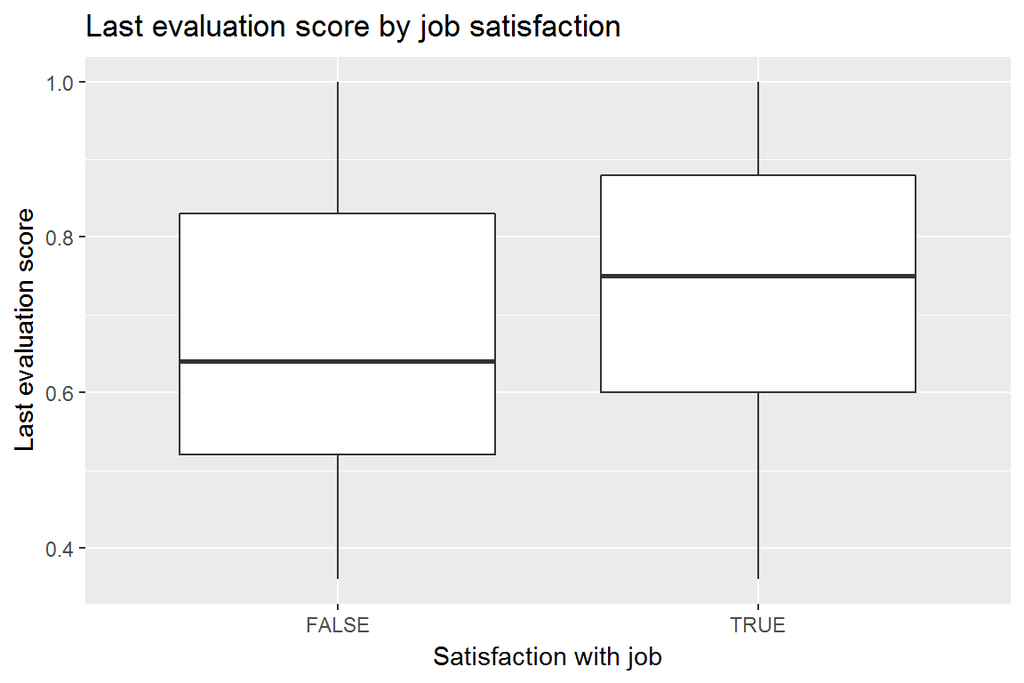

```r
g1 <- ggplot(hr_sales, aes(x = satisfied, y= last_evaluation))
g1 + geom_boxplot(aes()) + xlab("Satisfaction with job") + ylab("Last evaluation score") + ggtitle("Last evaluation score by job satisfaction")
```

### Number of projects

On the one hand, it looks like that employees who are satisfied with their jobs tend to work on more projects. Middle 50% of employees that are happy with their jobs work on 3-5 projects with a mean of 4, compared to 2-5 project with a mean of 3 of those who are unsatisfied with their jobs. However, as can be seen in the plot, only those employees who are not satisfied with their jobs are working on more than 6 projects, which could mean that in order to gain satisfaction from job, one must feel that he/she is needed at the workplace but not exploited.

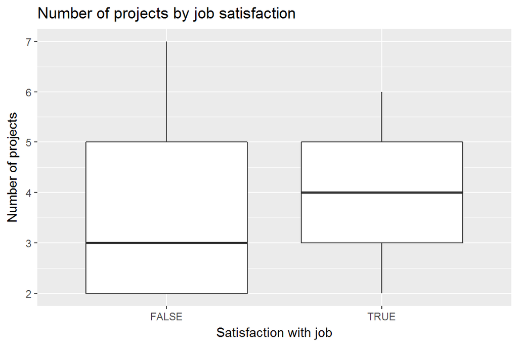

```r
g2 <- ggplot(hr_sales, aes(x = satisfied, y= number_project))
g2 + geom_boxplot(aes()) + xlab("Satisfaction with job") + ylab("Number of projects") + ggtitle("Number of projects by job satisfaction")
```

### Average monthly hours

Similar results are seen here as in the number of projects section. Which is again confirming that employees want to feel needed and important, however, not exploited.

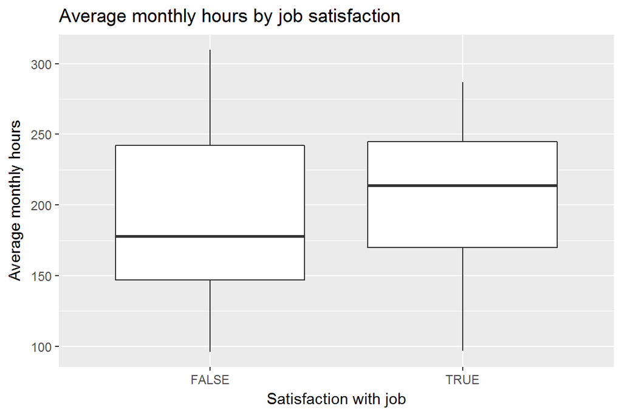

```r
g3 <- ggplot(hr_sales, aes(x = satisfied, y= average_montly_hours))
g3 + geom_boxplot(aes()) + xlab("Satisfaction with job") + ylab("Average monthly hours") + ggtitle("Average monthly hours by job satisfaction")
```

### Years spent in the company

```r
table_years <- xtabs(~satisfied+time_spend_company, data=hr_sales)
ftable(table_years)
```

```
##           time_spend_company   2   3   4   5   6   7   8  10
## satisfied
## FALSE                        292 928 401 138  69  42  14  28
## TRUE                         610 840 265 265 116  68  34  30
```

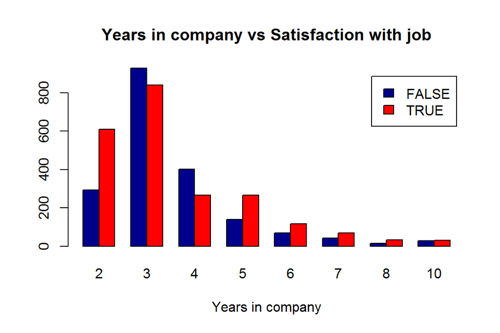

```r
counts_years <- table(hr_sales$satisfied, hr_sales$time_spend_company)
barplot(counts_years, main="Years in company vs Satisfaction with job",
  xlab="Years in company", col=c("darkblue","red"),
    legend = rownames(counts_years), beside=TRUE)
```

### Work accidents

This grapgh doesn’t indicate any clear relationship between work accidents and job satisfaction. However, the number of people who had an accident at work is really low compared to those who haven’t and in a field like sales it is highly unlikely that employees could get into very serious accidents related to work (compared to someone working at an assembly unit in a factory or dealing with some chemicals).

```r
table_accidents <- xtabs(~satisfied+Work_accident, data=hr_sales)
ftable(table_accidents)
```

```
##           Work_accident    0    1
## satisfied
## FALSE                   1680  232
## TRUE                    1873  355
```

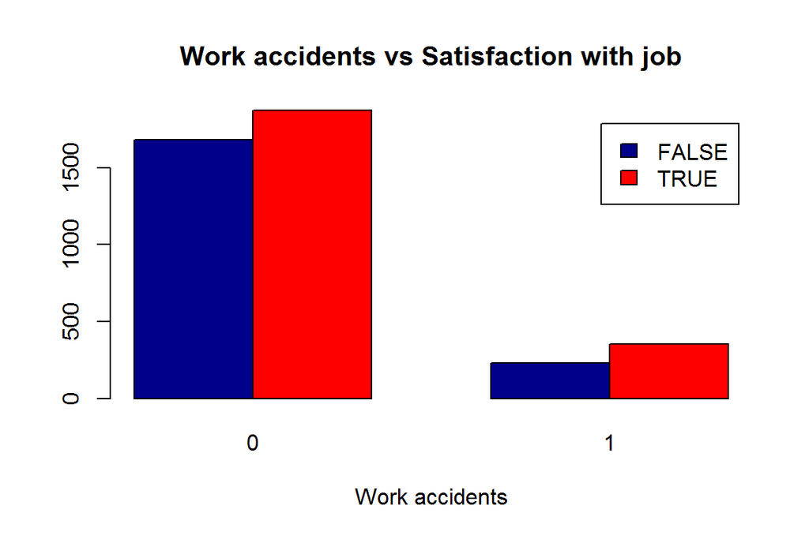

```r
counts_accidents <- table(hr_sales$satisfied, hr_sales$Work_accident)
barplot(counts_accidents, main="Work accidents vs Satisfaction with job",
  xlab="Work accidents", col=c("darkblue","red"),
    legend = rownames(counts_years), beside=TRUE)
```

### Promotion

```r
table_promotion <- xtabs(~satisfied+promotion_last_5years, data=hr_sales)
ftable(table_promotion)
```

```
##           promotion_last_5years    0    1
## satisfied
## FALSE                           1880   32
## TRUE                            2160   68
```

### Salary

```r
table_salary <- xtabs(~satisfied+salary, data=hr_sales)
ftable(table_salary)
```

```
##           salary high  low medium
## satisfied
## FALSE              99 1021    792
## TRUE              170 1078    980
```

# Analysis

The data will be analysed using logistic regression method to see whether the variables (selected predictors) are able to statistically significantly predict *satisfied* (whether or not employees are satisfied with their job).

## Method

The logistic regression is a method that allows us to estimate how probable it is to get one or the other value of a binary variable based on one or more independent variables.

In this case, the model will be fitted by adding those variables that seemed to have some relationship with *satisfied* in the variable analysis in the previous section. Thos variables are:  
1. last_evaluation - the result of last performance evaluation of the employee  
2. number_project - number of projects  
3. average_montly_hours - average monthly hours at work  
4. time_spend_company - years spent in the company  
5. salary - the level of salary (high, medium, low)

## Results

The fitted model shows that *number_project* does not have a statistically significant effect on the dependant variable. All other variables seem to have significance ranging from high to low.

```r
m <- glm(satisfied ~ last_evaluation + number_project + average_montly_hours + time_spend_company + salary, data = hr_sales, family = "binomial")

summary(m)
```

```
##
## Call:
## glm(formula = satisfied ~ last_evaluation + number_project +
##     average_montly_hours + time_spend_company + salary, family = "binomial",
##     data = hr_sales)
##
## Deviance Residuals:
##     Min       1Q   Median       3Q      Max
## -1.8010  -1.1430   0.8532   1.0760   1.6503
##
## Coefficients:
##                        Estimate Std. Error z value Pr(>|z|)
## (Intercept)          -1.3964914  0.2112287  -6.611 3.81e-11 ***
## last_evaluation       2.0020936  0.2069705   9.673  < 2e-16 ***
## number_project       -0.0461240  0.0295860  -1.559 0.119000
## average_montly_hours  0.0045553  0.0007314   6.228 4.72e-10 ***
## time_spend_company   -0.0506421  0.0216972  -2.334 0.019594 *
## salarylow            -0.5308397  0.1367789  -3.881 0.000104 ***
## salarymedium         -0.3666012  0.1381094  -2.654 0.007944 **
## ---
## Signif. codes:  0 '***' 0.001 '**' 0.01 '*' 0.05 '.' 0.1 ' ' 1
##
## (Dispersion parameter for binomial family taken to be 1)
##
##     Null deviance: 5715.1  on 4139  degrees of freedom
## Residual deviance: 5505.9  on 4133  degrees of freedom
## AIC: 5519.9
##
## Number of Fisher Scoring iterations: 4
```

```r
OR <- coef(m) %>% exp
CI <- confint(m) %>% exp
cbind(OR, CI)
```

```
##                             OR     2.5 %     97.5 %
## (Intercept)          0.2474637 0.1635382  0.3744068
## last_evaluation      7.4045420 4.9416434 11.1246322
## number_project       0.9549235 0.9010375  1.0118611
## average_montly_hours 1.0045657 1.0031289  1.0060098
## time_spend_company   0.9506188 0.9109843  0.9919019
## salarylow            0.5881109 0.4486138  0.7672889
## salarymedium         0.6930860 0.5273578  0.9066752
```

Now the model will be adjusted an only *last_evaluation* and *average_montly_hours* will be included in the model.

```r
m2 <- glm(satisfied ~ last_evaluation + average_montly_hours, data = hr_sales, family = "binomial")

summary(m2)
```

```
##
## Call:
## glm(formula = satisfied ~ last_evaluation + average_montly_hours,
##     family = "binomial", data = hr_sales)
##
## Deviance Residuals:
##     Min       1Q   Median       3Q      Max
## -1.6364  -1.1495   0.8664   1.0881   1.5793
##
## Coefficients:
##                        Estimate Std. Error z value Pr(>|z|)
## (Intercept)          -1.9679761  0.1646215 -11.955  < 2e-16 ***
## last_evaluation       1.8675629  0.1990548   9.382  < 2e-16 ***
## average_montly_hours  0.0039937  0.0006854   5.827 5.66e-09 ***
## ---
## Signif. codes:  0 '***' 0.001 '**' 0.01 '*' 0.05 '.' 0.1 ' ' 1
##
## (Dispersion parameter for binomial family taken to be 1)
##
##     Null deviance: 5715.1  on 4139  degrees of freedom
## Residual deviance: 5532.0  on 4137  degrees of freedom
## AIC: 5538
##
## Number of Fisher Scoring iterations: 4
```

Let’s look at the odd rations and their CIs. So it still looks quite similar to the first model with *last_evaluation* having the highest prediction effect.

```r
OR2 <- coef(m2) %>% exp
CI2 <- confint(m2) %>% exp
cbind(OR2, CI2)
```

```
##                            OR2     2.5 %    97.5 %
## (Intercept)          0.1397394 0.1010714 0.1927202
## last_evaluation      6.4725028 4.3859198 9.5717305
## average_montly_hours 1.0040017 1.0026553 1.0053533
```

The seconf model is used to create a prediction variable and then the prediction was used to see how many values the model predicted correctly.

The table shows that 23% out 39% of cases model correctly predicted low satisfaction with job, while 38% out of 61% of cases model correctly predicted high job satisfaction. It seems that the model is quite poor in predicting the values.

```r
probabilities <- predict(m2, type = "response")
hr_sales <- mutate(hr_sales, probability = probabilities)
hr_sales <- mutate(hr_sales, prediction = probability > 0.5 )

table(satisfied = hr_sales$satisfied, prediction = hr_sales$prediction) %>% prop.table() %>% addmargins()
```

```
##          prediction
## satisfied     FALSE      TRUE       Sum
##     FALSE 0.2285024 0.2333333 0.4618357
##     TRUE  0.1567633 0.3814010 0.5381643
##     Sum   0.3852657 0.6147343 1.0000000
```

Bellow, a penalty/loss rate is calculated to see how many times the fitted model has classified the observations incorrectly. The result shows that on average 39 cases were predicted incorrectly.

```r
loss_func <- function(class, prob) {
  n_wrong <- abs(class - prob) > 0.5
  mean(n_wrong)
}

loss_func(class = hr_sales$satisfied, prob = hr_sales$probability)
```

```
## [1] 0.3900966
```

```r
library(boot)
cv <- cv.glm(data = hr_sales, cost = loss_func, glmfit = m, K = 10)
cv$delta[1]
```

```
## [1] 0.3850242
```

# Discussion and conclusions

The original dataset was intended to be used for analysing why some employees leave their work prematurelly. However, I have decided to analyse what affects employee satisfaction with their job using the same dataset.

Average monthly hours indicated that employees seem to be more satisfied with their job if they work longer hours (meaning, full-time, rather than part-time). It could indicated that they are more commited and more connected to their job and their goals are more in-line with company’s goals.

Last performance evaluation score is highly related to job satisfaction. It probably has a couple of reasons for it. Firstly, it could indicate that employees who received higher score were actually better connected to the overall company’s vision and mission and therefore both performed better and were more satisfied with their job. Secondly, higher score to an employee can indicate that he or she is valued in the company and that the work he or she does is important, thus making the person feel more satisfied with their job.

Overall, it might have been a mistake to use this data for analysis job satisfaction with the data that was meant for analysing a different issue. Job satisfaction is depended on many different variables that were not part of this dataset, thus this question needs to be addressed using different data.